# Lazada Cross-Border E-Commerce Promotion Analysis

2024-12-18

# Section 1: Introduction & Objectives

## 1.1 Background

1.Lazada is a leading e-commerce platform in Southeast Asia, attracts global sellers and consumers through diverse promotional activities.

2.For merchants, understanding the effectiveness of these promotions is crucial for optimizing marketing strategies and enhancing platform competitiveness.

## 1.2 Objectives

This analysis focuses on Lazada’s cross-border e-commerce promotions, aiming to assess factors such as discount intensity and brand influence on sales, providing data-driven insights and support for marketing decisions in cross-border e-commerce.

Here are the questions we going to address:

### 1.Regression

Predict product sales and analyze the impact of factors.( eg. discount rates, ratings, and the number of reviews).

### 2.Classification

Identify which categories of products are more likely to achieve high sales through promotions.

## 1.3 Who is going to benefits

### 1.Cross-border merchants

For those who are looking to enter the cross-border e-commerce market or optimize promotional strategies to enhance the effectiveness of promotions.

### 2.E-commerce platforms

For companies who are aiming to refine their promotional policies and increase market share (e.g., Lazada、Shopee, Taobao etc.).

### 3.Supply chain and logistics service providers

For those who are seeking to better predict demand fluctuations, optimize inventory management, and improve delivery efficiency.

## 1.4 Data Source

https://www.kaggle.com/datasets/phucvr/lazada-crawl

# Section 2:Data understanding

## 2.1 Dataset overview

```r
library(dplyr)
library(readxl)
data <- read_excel("./wqd7004_dataset.xlsx")
head(data)
```

```
## # A tibble: 6 × 14
##       itemId name     brandName category originalPrice priceShow itemSoldCntShow
##        <dbl> <chr>    <chr>     <chr>            <dbl>     <dbl>           <dbl>
## 1  342230105 Origina… Xiaomi    Cellula…       3590000   3466863              72
## 2  464752465 Xiaomi … Xiaomi    Cellula…       5200000   2850000               5
## 3  709428868 Xiaomi … Xiaomi    Cellula…       2690000   1757000             288
## 4  895822931 Xiaomi … Xiaomi    Cellula…       2690000   1849000              52
## 5 1205582653 Phone X… Xiaomi    Cellula…       4890000   4890000              10
## 6 1277481768 Xiaomi … Xiaomi    Tablet         5090000   3999000              17
## # ℹ 7 more variables: discount <dbl>, ratingScore <dbl>, review <dbl>,
## #   location <chr>, sellerName <chr>, sellerId <dbl>, brandId <dbl>
```

```r
#The number of rows and columns

nrow(data)
```

```
## [1] 3586
```

```r
ncol(data)
```

```
## [1] 14
```

```r
dim(data)
```

```
## [1] 3586   14
```

```r
names(data)
```

```
##  [1] "itemId"          "name"            "brandName"       "category"
##  [5] "originalPrice"   "priceShow"       "itemSoldCntShow" "discount"
##  [9] "ratingScore"     "review"          "location"        "sellerName"
## [13] "sellerId"        "brandId"
```

```r
#Type of data
sapply(data, class)
```

```
##          itemId            name       brandName        category   originalPrice
##       "numeric"     "character"     "character"     "character"       "numeric"
##       priceShow itemSoldCntShow        discount     ratingScore          review
##       "numeric"       "numeric"       "numeric"       "numeric"       "numeric"
##        location      sellerName        sellerId         brandId
##     "character"     "character"       "numeric"       "numeric"
```

```r
#Data distribution
summary(data)
```

```
##      itemId              name            brandName           category
##  Min.   :2.542e+08   Length:3586        Length:3586        Length:3586
##  1st Qu.:2.273e+09   Class :character   Class :character   Class :character
##  Median :2.427e+09   Mode  :character   Mode  :character   Mode  :character
##  Mean   :2.377e+09
##  3rd Qu.:2.593e+09
##  Max.   :2.671e+09
##  originalPrice        priceShow        itemSoldCntShow       discount
##  Min.   :    1399   Min.   :    1399   Min.   :     0.0   Min.   : 0.00
##  1st Qu.: 1200000   1st Qu.:  837328   1st Qu.:     0.0   1st Qu.:15.00
##  Median : 2150299   Median : 1131232   Median :     5.0   Median :43.00
##  Mean   : 3834455   Mean   : 2813634   Mean   :   262.8   Mean   :33.45
##  3rd Qu.: 3388000   3rd Qu.: 2596000   3rd Qu.:    57.0   3rd Qu.:50.00
##  Max.   :44490000   Max.   :39890000   Max.   :128000.0   Max.   :72.00
##   ratingScore        review          location          sellerName
##  Min.   :0.000   Min.   :   0.00   Length:3586        Length:3586
##  1st Qu.:0.000   1st Qu.:   0.00   Class :character   Class :character
##  Median :4.622   Median :   1.00   Mode  :character   Mode  :character
##  Mean   :2.686   Mean   :  26.46
##  3rd Qu.:5.000   3rd Qu.:  41.00
##  Max.   :5.000   Max.   :2886.00
##     sellerId            brandId
##  Min.   :1.276e+04   Min.   :      667
##  1st Qu.:2.002e+11   1st Qu.:    65074
##  Median :2.003e+11   Median :   134666
##  Mean   :1.800e+11   Mean   : 59893744
##  3rd Qu.:2.003e+11   3rd Qu.:127167201
##  Max.   :2.007e+11   Max.   :127221667
```

## 2.2 Verify Data Quality

### 2.2.1 Check missing value

```r
missing_val <- colSums(is.na(data))
print(missing_val)
```

```
##          itemId            name       brandName        category   originalPrice
##               0               0               0               0               0
##       priceShow itemSoldCntShow        discount     ratingScore          review
##               0               0               0               0               0
##        location      sellerName        sellerId         brandId
##               0               0               0               0
```

### 2.2.2 Check validity of the dataset

```r
#check itemId
itemId_positive_int <- all(data$itemId > 0 & data$itemId %% 1 == 0, na.rm = TRUE)
itemId_unique <- length(data$itemId) == length(unique(data$itemId))

if (itemId_positive_int & itemId_unique) {
  cat("itemId:All values are positive integers and unique.\n")
} else {
  cat("itemId:The value of the existence of positive integer or duplicate values.\n")
}
```

```
## itemId:All values are positive integers and unique.
```

```r
##check priceShow&originalPrice
priceShow_positive<-all(data$priceShow > 0,na.rm = TRUE)
originalPrice_positive<-all(data$originalPrice > 0,na.rm = TRUE)

if (priceShow_positive & originalPrice_positive) {
  cat("priceShow: All values are positive.\n")
  cat("originalPrice: All values are positive.\n")
} else {
  cat("Non-positive values exist.")
}
```

```
## priceShow: All values are positive.
## originalPrice: All values are positive.
```

```r
##check discount
if(all(data$discount>=0 & data$discount<100)){
  cat("discount:All values are between 0 and 100.\n")
}else{
  cat("discount:An invalid value exists.\n")
}
```

```
## discount:All values are between 0 and 100.
```

```r
##check ratingScore
if(all(data$ratingScore>=0 & data$ratingScore<=5)){
  cat("ratingScore:All values are between 0 and 5.\n")
}else{
  cat("ratingScore:An invalid value exists.\n")
}
```

```
## ratingScore:All values are between 0 and 5.
```

```r
##check Review and itemSoldCntShow
review<-all(data$review >= 0 & data$review %% 1 == 0,na.rm = TRUE)
itemSoldCntShow<-all(data$itemSoldCntShow >= 0 & data$itemSoldCntShow %% 1 == 0,na.rm = TRUE)


if (review & itemSoldCntShow) {
  cat("review: All values are non-negative integers.\n")
  cat("itemSoldCntShow: All values are non-negative integers.\n")
} else {
  cat("An invalid value exists.")
}
```

```
## review: All values are non-negative integers.
## itemSoldCntShow: All values are non-negative integers.
```

## 2.3 Univariate analysis

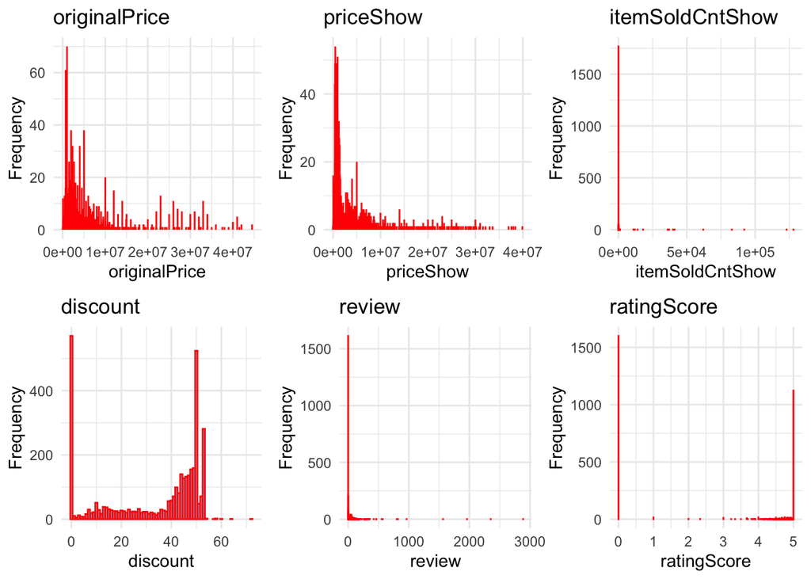

```r
library(ggplot2)
library(gridExtra)
library(rlang)

barplot <- function(data, column_name) {
  ggplot(data, aes(x = !!sym(column_name))) +  # 使用 !!sym() 代替 aes_string()
    geom_bar(fill = "skyblue", color = "red") +
    labs(title = paste(column_name), x = column_name, y = "Frequency") +
    theme_minimal()
}

p1 <- barplot(data, "originalPrice")
p2 <- barplot(data, "priceShow")
p3 <- barplot(data, "itemSoldCntShow")
p4 <- barplot(data, "discount")
p5 <- barplot(data, "review")
p6 <- barplot(data, "ratingScore")

grid.arrange(p1, p2, p3, p4, p5, p6, ncol = 3)
```

## 2.4 Multivariate analysis

```r
library(ggplot2)
library(reshape2)
library(readxl)
head(data)
```

```
## # A tibble: 6 × 14
##       itemId name     brandName category originalPrice priceShow itemSoldCntShow
##        <dbl> <chr>    <chr>     <chr>            <dbl>     <dbl>           <dbl>
## 1  342230105 Origina… Xiaomi    Cellula…       3590000   3466863              72
## 2  464752465 Xiaomi … Xiaomi    Cellula…       5200000   2850000               5
## 3  709428868 Xiaomi … Xiaomi    Cellula…       2690000   1757000             288
## 4  895822931 Xiaomi … Xiaomi    Cellula…       2690000   1849000              52
## 5 1205582653 Phone X… Xiaomi    Cellula…       4890000   4890000              10
## 6 1277481768 Xiaomi … Xiaomi    Tablet         5090000   3999000              17
## # ℹ 7 more variables: discount <dbl>, ratingScore <dbl>, review <dbl>,
## #   location <chr>, sellerName <chr>, sellerId <dbl>, brandId <dbl>
```

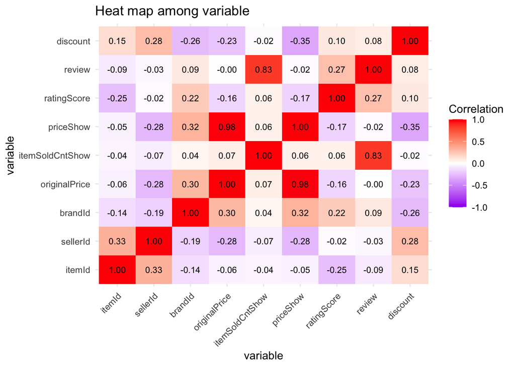

```r
numeric <- data[, c("itemId","sellerId","brandId","originalPrice","itemSoldCntShow", "priceShow","ratingScore", "review","discount")]
matrix <- cor(numeric, use = "complete.obs")  # "complete.obs"
melted <- melt(matrix)

ggplot(melted, aes(Var1, Var2, fill = value)) +
  geom_tile() +
  geom_text(aes(label = sprintf("%.2f", value)), color = "black", size = 3) +
  scale_fill_gradient2(low = "purple", high = "red", mid = "white", midpoint = 0, limit = c(-1, 1)) +
  labs(title = "Heat map among variable", x = "variable", y = "variable", fill = "Correlation") +
  theme_minimal() +
  theme(axis.text.x = element_text(angle = 45, hjust = 1))
```

# Section 3 :Data preparation

## 3.1 Clean and Prepare Data

```r
# Load necessary libraries
library(tidyr)
library(knitr)
library(stringr)
library(kableExtra)
library(caret)  # For data set partitioning
# Step 1: Clear column names
names(data) <- gsub(" ", "_", names(data))  # Replace spaces with underscores

# Step 2: Convert columns to appropriate data types
data$category <- as.factor(data$category)
data$originalPrice <- as.numeric(data$originalPrice)
data$priceShow <- as.numeric(data$priceShow)
data$itemSoldCntShow <- as.numeric(data$itemSoldCntShow)
data$discount <- as.numeric(data$discount)
data$ratingScore <- as.numeric(data$ratingScore)
data$review <- as.numeric(data$review)

# Step 3: Handle missing values
data <- data %>%
  filter(!is.na(originalPrice) & !is.na(priceShow) &
         !is.na(itemSoldCntShow) & !is.na(discount))

# Step 4: Handle outliers
## Function to remove outliers based on IQR
remove_outliers <- function(df, var) {
  Q1 <- quantile(df[[var]], 0.25)
  Q3 <- quantile(df[[var]], 0.75)
  IQR <- Q3 - Q1

  lower_bound <- Q1 - 1.5 * IQR
  upper_bound <- Q3 + 1.5 * IQR

  df <- df %>% filter(df[[var]] >= lower_bound & df[[var]] <= upper_bound)
  return(df)
}

## Loop through numeric columns and remove outliers
numeric_columns <- sapply(data, is.numeric)
for (col in names(data)[numeric_columns]) {
  data <- remove_outliers(data, col)
}

# Step 5: Create new feature variable (Sales Score) with normalization and weights
data <- data %>%
  mutate(
    normalized_sales = (itemSoldCntShow - min(itemSoldCntShow)) /
                       (max(itemSoldCntShow) - min(itemSoldCntShow)),
    normalized_rating = (ratingScore - min(ratingScore)) /
                        (max(ratingScore) - min(ratingScore)),

    sales_score = (normalized_sales * 0.7) + (normalized_rating * 0.3)  # Setting weights
  )

# Step 6: Clean 'sellerName' and handle 'name' column
data <- data %>%
  mutate(
    sellerName = str_replace_all(sellerName, "[\u4e00-\u9fa5]", ""),  # Remove Chinese characters
    sellerName = str_trim(sellerName),  # Trim whitespace
    name = ifelse(nchar(name) > 10, paste0(substr(name, 1, 10), "..."), name)  # Truncate 'name' column
  )

# Step 7: Display cleaned data
kable(head(data), format = "html", caption = "Prepared Dataset") %>%
  kable_styling("striped", full_width = F)
```

Prepared Dataset

| itemId | name | brandName | category | originalPrice | priceShow | itemSoldCntShow | discount | ratingScore | review | location | sellerName | sellerId | brandId | normalized_sales | normalized_rating | sales_score |
| --- | --- | --- | --- | --- | --- | --- | --- | --- | --- | --- | --- | --- | --- | --- | --- | --- |
| 2033044000 | Xiaomi MiM… | Xiaomi | Cellular phone | 1600000 | 930468 | 45 | 42 | 4.652 | 23 | Ho Chi Minh | TAY NGUYEN STORE 47 | 200169939195 | 4348 | 0.2571429 | 0.9304 | 0.45912 |
| 2033070723 | Xiaomi Mi8… | Xiaomi | Cellular phone | 3150000 | 1674657 | 30 | 47 | 5.000 | 20 | Ho Chi Minh | TAY NGUYEN STORE 47 | 200169939195 | 4348 | 0.1714286 | 1.0000 | 0.42000 |
| 2033123603 | Xiaomi MiM… | Xiaomi | Cellular phone | 1500000 | 930468 | 37 | 38 | 4.611 | 18 | Ho Chi Minh | TAY NGUYEN STORE 47 | 200169939195 | 4348 | 0.2114286 | 0.9222 | 0.42466 |
| 2033161146 | Xiaomi Mi8… | Xiaomi | Cellular phone | 4050000 | 2141288 | 28 | 47 | 5.000 | 17 | Ho Chi Minh | TAY NGUYEN STORE 47 | 200169939195 | 4348 | 0.1600000 | 1.0000 | 0.41200 |
| 2033266624 | Genuine Xi… | Xiaomi | Cellular phone | 1999000 | 1116748 | 82 | 44 | 4.815 | 65 | Ho Chi Minh | TAY NGUYEN STORE 47 | 200169939195 | 4348 | 0.4685714 | 0.9630 | 0.61690 |
| 2033406937 | Genuine Xi… | Xiaomi | Cellular phone | 2850000 | 1535878 | 28 | 46 | 5.000 | 16 | Ho Chi Minh | TAY NGUYEN STORE 47 | 200169939195 | 4348 | 0.1600000 | 1.0000 | 0.41200 |

```r
# Step 8: Save the cleaned dataset
write.csv(data, "prepared_dataset.csv", row.names = FALSE)
```

## 3.2 Split the Dataset

```r
# Split the dataset into training and testing sets
set.seed(123)  # For reproducibility
train_index <- createDataPartition(data$sales_score, p = .8,  # 80% As a training set
                                    list = FALSE,
                                    times = 1)  # List is FALSE Return index

train_data <- data[train_index, ]  # Training Data
test_data <- data[-train_index, ]   # Test Data
```

## 3.3 Display Prepared Datasets

```r
# Display the first few rows of the prepared training data
kable(head(train_data), format = "html", caption = "Training Dataset") %>%
  kable_styling("striped", full_width = F)
```

Training Dataset

| itemId | name | brandName | category | originalPrice | priceShow | itemSoldCntShow | discount | ratingScore | review | location | sellerName | sellerId | brandId | normalized_sales | normalized_rating | sales_score |
| --- | --- | --- | --- | --- | --- | --- | --- | --- | --- | --- | --- | --- | --- | --- | --- | --- |
| 2033044000 | Xiaomi MiM… | Xiaomi | Cellular phone | 1600000 | 930468 | 45 | 42 | 4.652 | 23 | Ho Chi Minh | TAY NGUYEN STORE 47 | 200169939195 | 4348 | 0.2571429 | 0.9304 | 0.45912 |
| 2033123603 | Xiaomi MiM… | Xiaomi | Cellular phone | 1500000 | 930468 | 37 | 38 | 4.611 | 18 | Ho Chi Minh | TAY NGUYEN STORE 47 | 200169939195 | 4348 | 0.2114286 | 0.9222 | 0.42466 |
| 2033266624 | Genuine Xi… | Xiaomi | Cellular phone | 1999000 | 1116748 | 82 | 44 | 4.815 | 65 | Ho Chi Minh | TAY NGUYEN STORE 47 | 200169939195 | 4348 | 0.4685714 | 0.9630 | 0.61690 |
| 2033406937 | Genuine Xi… | Xiaomi | Cellular phone | 2850000 | 1535878 | 28 | 46 | 5.000 | 16 | Ho Chi Minh | TAY NGUYEN STORE 47 | 200169939195 | 4348 | 0.1600000 | 1.0000 | 0.41200 |
| 2034907442 | Genuine Xi… | Xiaomi | Cellular phone | 1599000 | 930468 | 114 | 42 | 5.000 | 96 | Ho Chi Minh | TAY NGUYEN STORE 47 | 200169939195 | 4348 | 0.6514286 | 1.0000 | 0.75600 |
| 2035034952 | Genuine Xi… | Xiaomi | Cellular phone | 1350000 | 837328 | 38 | 38 | 4.684 | 19 | Ho Chi Minh | TAY NGUYEN STORE 47 | 200169939195 | 4348 | 0.2171429 | 0.9368 | 0.43304 |

```r
# Display the first few rows of the prepared testing data
kable(head(test_data), format = "html", caption = "Testing Dataset") %>%
  kable_styling("striped", full_width = F)
```

Testing Dataset

| itemId | name | brandName | category | originalPrice | priceShow | itemSoldCntShow | discount | ratingScore | review | location | sellerName | sellerId | brandId | normalized_sales | normalized_rating | sales_score |
| --- | --- | --- | --- | --- | --- | --- | --- | --- | --- | --- | --- | --- | --- | --- | --- | --- |
| 2033070723 | Xiaomi Mi8… | Xiaomi | Cellular phone | 3150000 | 1674657 | 30 | 47 | 5.000 | 20 | Ho Chi Minh | TAY NGUYEN STORE 47 | 200169939195 | 4348 | 0.1714286 | 1.0000 | 0.42000 |
| 2033161146 | Xiaomi Mi8… | Xiaomi | Cellular phone | 4050000 | 2141288 | 28 | 47 | 5.000 | 17 | Ho Chi Minh | TAY NGUYEN STORE 47 | 200169939195 | 4348 | 0.1600000 | 1.0000 | 0.41200 |
| 2035335256 | Xiaomi Red… | Xiaomi | Cellular phone | 2400000 | 1208957 | 75 | 50 | 4.862 | 65 | Ho Chi Minh | TAY NGUYEN STORE 47 | 200169939195 | 4348 | 0.4285714 | 0.9724 | 0.59172 |
| 2035948704 | Xiaomi Mim… | Xiaomi | Cellular phone | 1100000 | 604478 | 34 | 45 | 4.545 | 22 | Ho Chi Minh | TAY NGUYEN STORE 47 | 200169939195 | 4348 | 0.1942857 | 0.9090 | 0.40870 |
| 2036324094 | Genuine Xi… | Xiaomi | Cellular phone | 1950000 | 929537 | 35 | 52 | 5.000 | 18 | Ho Chi Minh | TAY NGUYEN STORE 47 | 200169939195 | 4348 | 0.2000000 | 1.0000 | 0.44000 |
| 2036369720 | Xiaomi Red… | Xiaomi | Cellular phone | 668000 | 361573 | 141 | 46 | 4.956 | 114 | Ho Chi Minh | TAY NGUYEN STORE 47 | 200169939195 | 4348 | 0.8057143 | 0.9912 | 0.86136 |

# Section 4:Exploratory Data Analysis

## 4.1 Data Visualization

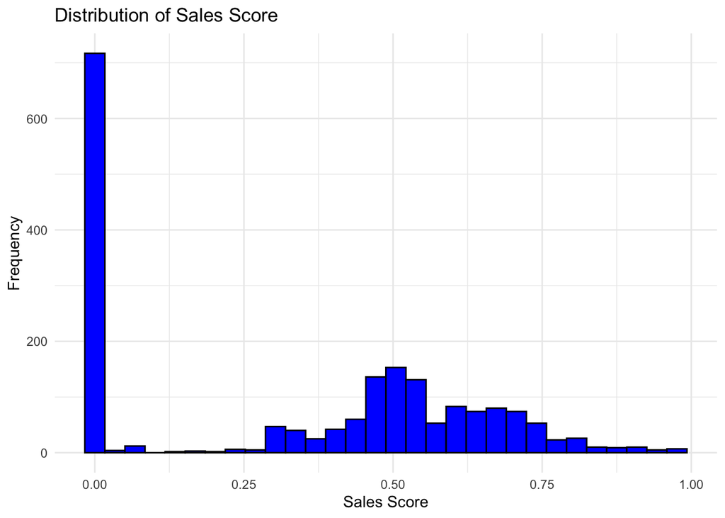

```r
# Load necessary libraries
library(readr)
library(ggplot2)
library(dplyr)
library(corrplot)

# 1. Load the dataset
data <- read_csv("prepared_dataset.csv")

# 2. Explore Key Features

## 2.1 Distribution of Sales Score
ggplot(data, aes(x = sales_score)) +
  geom_histogram(bins = 30, fill = "blue", color = "black") +
  labs(title = "Distribution of Sales Score", x = "Sales Score", y = "Frequency") +
  theme_minimal()  # Ensure using theme_minimal() here
```

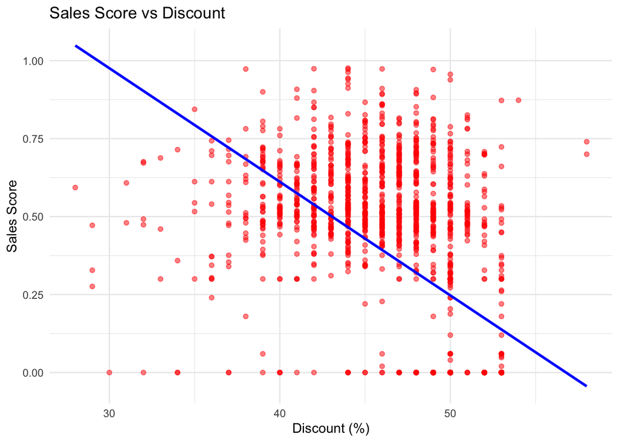

```r
## 2.2 Sales Score vs Discount
ggplot(data, aes(x = discount, y = sales_score)) +
  geom_point(alpha = 0.5, color = "red") +
  geom_smooth(method = "lm", se = FALSE, color = "blue") +
  labs(title = "Sales Score vs Discount", x = "Discount (%)", y = "Sales Score") +
  theme_minimal()
```

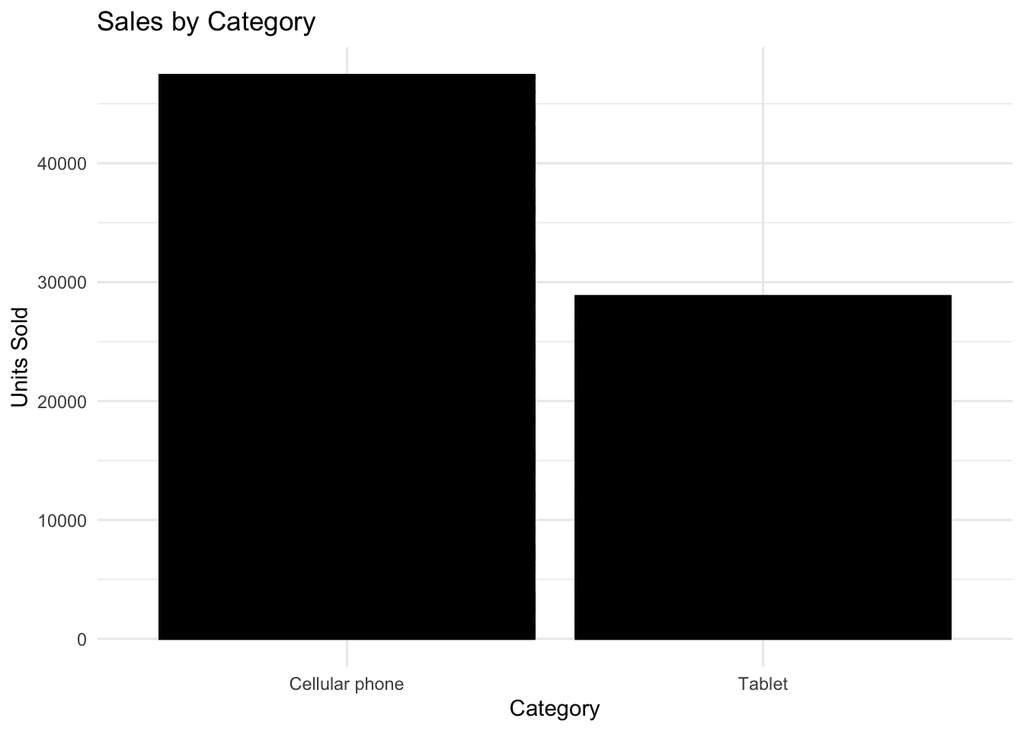

```r
## 2.3 Sales by Category
ggplot(data, aes(x = category, y = itemSoldCntShow)) +
  geom_bar(stat = "identity", fill = "purple", color = "black") +
  labs(title = "Sales by Category", x = "Category", y = "Units Sold") +
  theme(axis.text.x = element_text(angle = 45, hjust = 1)) +
  theme_minimal()
```

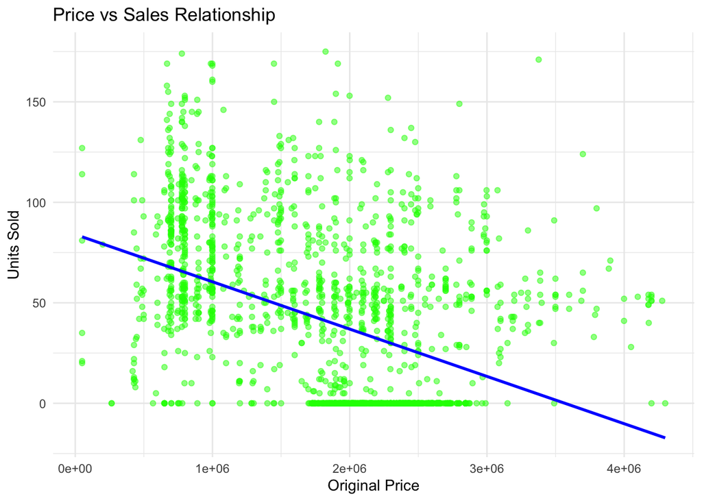

```r
## 2.4 Price vs Sales Relationship
ggplot(data, aes(x = originalPrice, y = itemSoldCntShow)) +
  geom_point(alpha = 0.5, color = "green") +
  geom_smooth(method = "lm", se = FALSE, color = "blue") +
  labs(title = "Price vs Sales Relationship", x = "Original Price", y = "Units Sold") +
  theme_minimal()
```

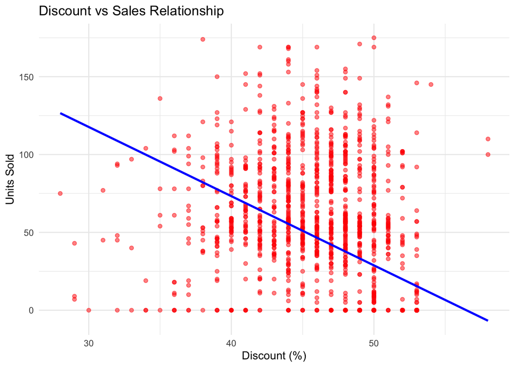

```r
## 2.5 Discount vs Sales Relationship
ggplot(data, aes(x = discount, y = itemSoldCntShow)) +
  geom_point(alpha = 0.5, color = "red") +
  geom_smooth(method = "lm", se = FALSE, color = "blue") +
  labs(title = "Discount vs Sales Relationship", x = "Discount (%)", y = "Units Sold") +
  theme_minimal()
```

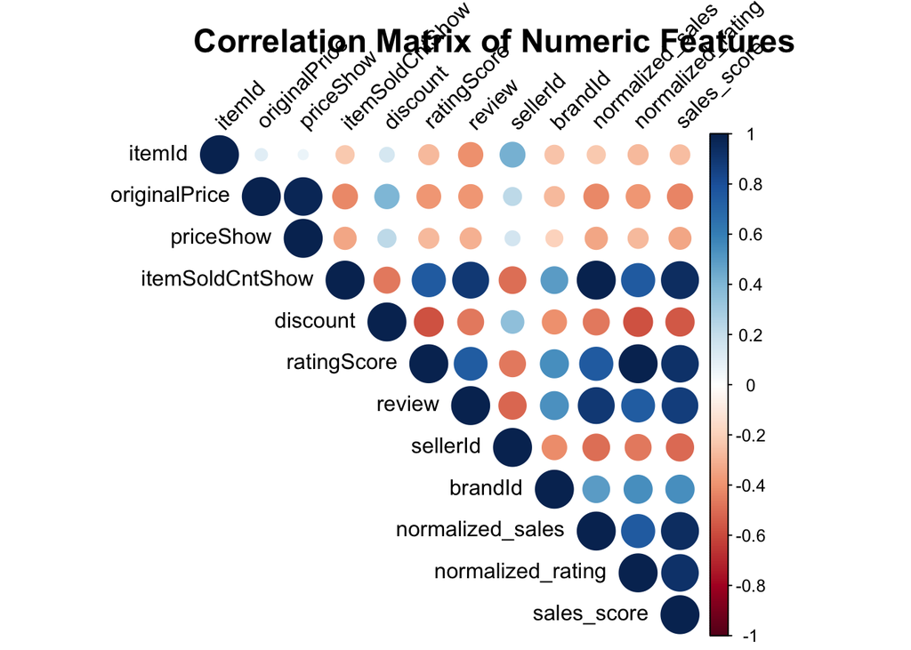

```r
## 2.6 Correlation Analysis
# Select numeric columns
numeric_data <- data %>% select(where(is.numeric))
# Calculate the correlation matrix
correlation_matrix <- cor(numeric_data, use = "complete.obs")

# Set up the graphical parameters
par(mar = c(5, 4, 5, 1))  # Top margin increased further to create space for the title

# Create the correlation plot without title
corrplot(correlation_matrix, method = "circle", type = "upper",
         tl.col = "black", tl.srt = 45,
         addgrid.col = NA)  # Optionally remove grid lines for clarity

# Add the title manually
title(main = "Correlation Matrix of Numeric Features", cex.main = 1.5, line = 3)
```